# Variational Auto-Encoder for MNIST

An implementation of variational auto-encoder (VAE) for the MNIST dataset described in the paper:  
* [Auto-Encoding Variational Bayes](https://arxiv.org/pdf/1312.6114) by Kingma et al.

## Results

### Reproducing an Image

We reproduce Figure 5 in the paper, showing performance of learned generative models for different latent variable dimensions.  
The following results can be reproduced with command:

```
python run_main.py --dim_z <each value> --num_epochs 60
```

Input image

2-D latent space

5-D latent space

10-D latent space

20-D latent space

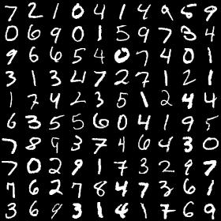

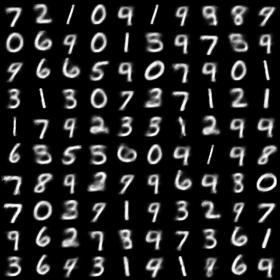

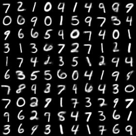

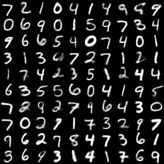

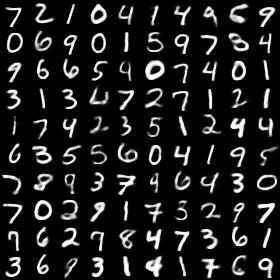

### Denoising

When training, salt & pepper noise is added to input image, so that VAE can reduce noise and restore original input image.  
The following results can be reproduced with command:

```
python run_main.py --dim_z 20 --add_noise True --num_epochs 40
```

Original input image

Input image with noise

Restored image via VAE

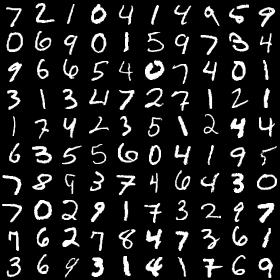

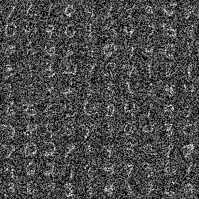

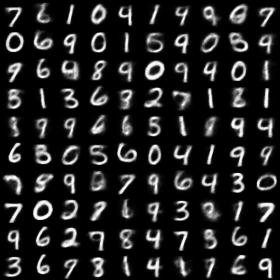

### Learned MNIST manifold

Visualizations of learned data manifold for generative models with 2-dim. latent space are given in Figure. 4 in the paper.  
The following results can be reproduced with command:

```
python run_main.py --dim_z 2 --num_epochs 60 --PMLR True
```

Learned MNIST manifold

Distribution of labeled data

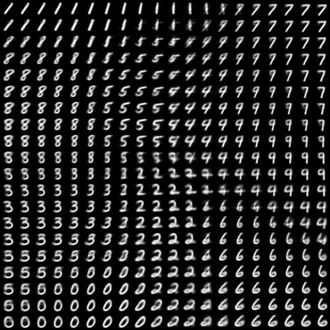

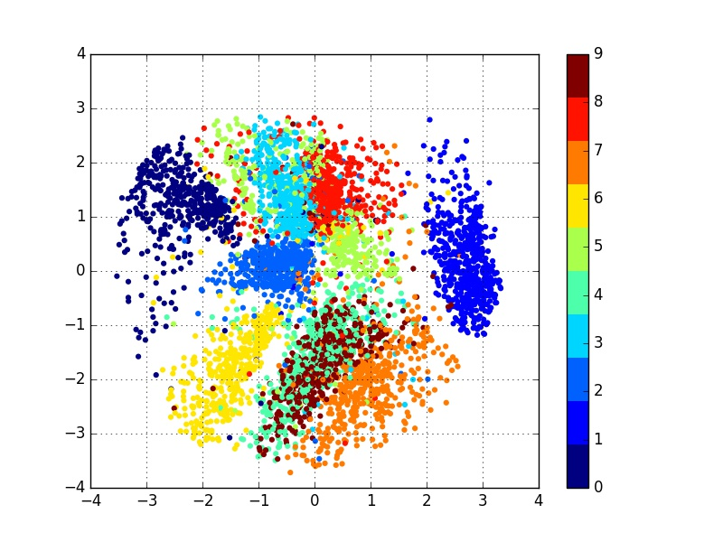

## Usage

### Prerequisites

1. Tensorflow
2. Python packages : numpy, scipy, PIL(or Pillow), matplotlib

### Command

```
python run_main.py --dim_z <latent vector dimension>
```

*Example*: `python run_main.py --dim_z 20`

### Arguments

*Required* :  
* `--dim_z`: Dimension of latent vector. *Default*: `20`

*Optional* :  
* `--results_path`: File path of output images. *Default*: `results` * `--add_noise`: Boolean for adding salt & pepper noise to input image. *Default*: `False` * `--n_hidden`: Number of hidden units in MLP. *Default*: `500` * `--learn_rate`: Learning rate for Adam optimizer. *Default*: `1e-3` * `--num_epochs`: The number of epochs to run. *Default*: `20` * `--batch_size`: Batch size. *Default*: `128` * `--PRR`: Boolean for plot-reproduce-result. *Default*: `True` * `--PRR_n_img_x`: Number of images along x-axis. *Default*: `10` * `--PRR_n_img_y`: Number of images along y-axis. *Default*: `10` * `--PRR_resize_factor`: Resize factor for each displayed image. *Default*: `1.0` * `--PMLR`: Boolean for plot-manifold-learning-result. *Default*: `False` * `--PMLR_n_img_x`: Number of images along x-axis. *Default*: `20` * `--PMLR_n_img_y`: Number of images along y-axis. *Default*: `20` * `--PMLR_resize_factor`: Resize factor for each displayed image. *Default*: `1.0` * `--PMLR_n_samples`: Number of samples in order to get distribution of labeled data. *Default*: `5000`

## References

This code is from:  
[1] https://github.com/hwalsuklee/tensorflow-mnist-VAE

The above implementation is based on these projects:  
[1] https://github.com/oduerr/dl_tutorial/tree/master/tensorflow/vae  
[2] https://github.com/fastforwardlabs/vae-tf/tree/master  
[3] https://github.com/kvfrans/variational-autoencoder  
[4] https://github.com/altosaar/vae